# Lung cancer Survival Analysis and Survival Models comparison

Damian Żamojda 386905

Karolina Szczęsna 415989

Rafał Rysiejko 423827

5/23/2021

# Libraries

```r
library(survival)
library(survminer)
library(tidyverse)
library(devtools)
library(eha)
library(ggplot2)
library(waffle)
library(hrbrthemes)
```

# Methodology

Our research aims at patients’ lung cancer survival analysis from North Central Cancer Treatment Group. In the analysis we did a detailed research on the variables that determine whether patients get over a disease or surrender in a certain duration time. Thus we used a non-parametric statistic estimator to create a Kaplan-Meier Survival model to measure the survival function from lifetime duration data. We conducted the comparison of both ECOG and Karnofsky Performance Score indicators and designed the formula of lung cancer survival where time is a dependent variable. The parametric models we used have varied distributions and are as follows: Weibull Model, Gompertz Model, Lognormal Model and Extreme Values.

# EDA

## Data Description

In order to provide the model, a summary of the lung cancer data is required. The dataset consists of 167 observations and 10 variables. The variables descriptions are as follows:

- inst - Institution code, where a patient was assigned
- time - survival time of a patient in days
- status - censoring status, where 1=censored, 2=dead
- age - patient’s age in years
- sex: - patient’s gender, where Male=0 Female=1
- ph.ecog - ECOG performance score, which indicates the the patient’s performance status on general well-being with cancer, where
  - 0= Asymptomatic
  - 1= Symptomatic but completely ambulatory
  - 2= Symptomatic, <50% in bed during the day
  - 3= Symptomatic, >50% in bed, but not bedbound
  - 4= Bed Bound
  - 5= Death
- ph.karno - Karnofsky performance score rated by physician, which indicates a detailed classification of general status and quality of life while having cancer, scale has a range from 100 to 0, where 100 = perfect state, 0 = death.
- pat.karno - Karnofsky performance score as rated by patient, same range as above
- meal.cal - calories consumed at meals daily by a patient (in kcal)
- wt.loss - patient’s weight loss in last six months (in kg)

## Summary Statistics

Regarding the time variable, the number of days survived after the lung cancer diagnosis differs a lot for all the patients. The minimum value shows only 5 days, whereas the maximum value - 1022 days. On average, patients maintained 309 days, which is around 10 months in a disease.

The age of patients concerns a wider range as well .The youngest patient with lung cancer had 39 years, while the oldest patient was 82 years old. The mean shows that 62 years is approximately an average age of a patient.

Calories consumed at meals by a patient range from only 96 kcal per day to a standard demand in a healthy person, which is 2600 kcal per day. Surprisingly, the mean value shows that on average 929.1 kcal is consumed daily.

```
##   X.1 X inst time status age sex ph.ecog ph.karno pat.karno meal.cal wt.loss
## 1   2 2    3  455      2  68   1       0       90        90     1225      15
## 2   4 4    5  210      2  57   1       1       90        60     1150      11
## 3   6 6   12 1022      1  74   1       1       50        80      513       0
## 4   7 7    7  310      2  68   2       2       70        60      384      10
## 5   8 8   11  361      2  71   2       2       60        80      538       1
## 6   9 9    1  218      2  53   1       1       70        80      825      16
```

```
##       inst            time            status            age
##  Min.   : 1.00   Min.   :   5.0   Min.   :0.0000   Min.   :39.00
##  1st Qu.: 3.00   1st Qu.: 174.5   1st Qu.:0.0000   1st Qu.:57.00
##  Median :11.00   Median : 268.0   Median :1.0000   Median :64.00
##  Mean   :10.71   Mean   : 309.9   Mean   :0.7186   Mean   :62.57
##  3rd Qu.:15.00   3rd Qu.: 419.5   3rd Qu.:1.0000   3rd Qu.:70.00
##  Max.   :32.00   Max.   :1022.0   Max.   :1.0000   Max.   :82.00
##       sex            ph.ecog          ph.karno        pat.karno
##  Min.   :0.0000   Min.   :0.0000   Min.   : 50.00   Min.   : 30.00
##  1st Qu.:0.0000   1st Qu.:0.0000   1st Qu.: 70.00   1st Qu.: 70.00
##  Median :0.0000   Median :1.0000   Median : 80.00   Median : 80.00
##  Mean   :0.3832   Mean   :0.9581   Mean   : 82.04   Mean   : 79.58
##  3rd Qu.:1.0000   3rd Qu.:1.0000   3rd Qu.: 90.00   3rd Qu.: 90.00
##  Max.   :1.0000   Max.   :3.0000   Max.   :100.00   Max.   :100.00
##     meal.cal         wt.loss
##  Min.   :  96.0   Min.   :-24.000
##  1st Qu.: 619.0   1st Qu.:  0.000
##  Median : 975.0   Median :  7.000
##  Mean   : 929.1   Mean   :  9.719
##  3rd Qu.:1162.5   3rd Qu.: 15.000
##  Max.   :2600.0   Max.   : 68.000
```

## Visualization

The histograms below show the distribution of observation in all numeric variables. Horizontal axis represents the values of observations, while the vertical axis “count” shows the amount of certain observations for each value.

Time histogram illustrates positive skew distribution. The right tailor indicates that the majority of observations are concentrated in a short time period - (0,500) days.

Meal.cal histogram represents positive skewness with the most visible increase around 1000 kcal consumed by a patient a day. It shows that patients rather refuse to fulfill daily demand for calories.

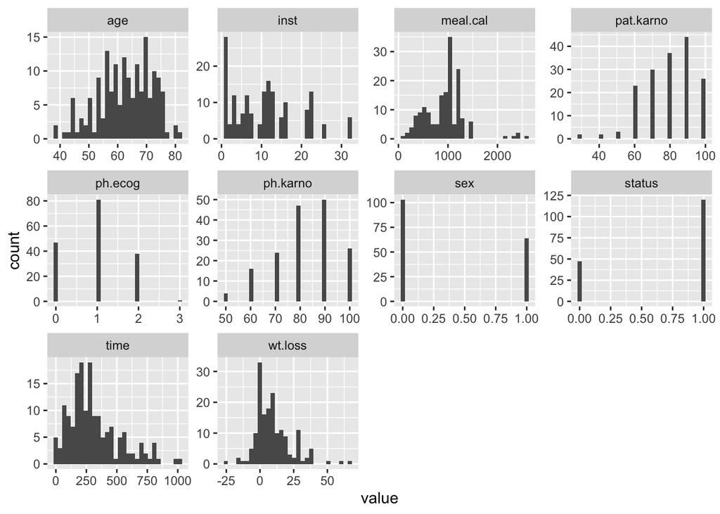

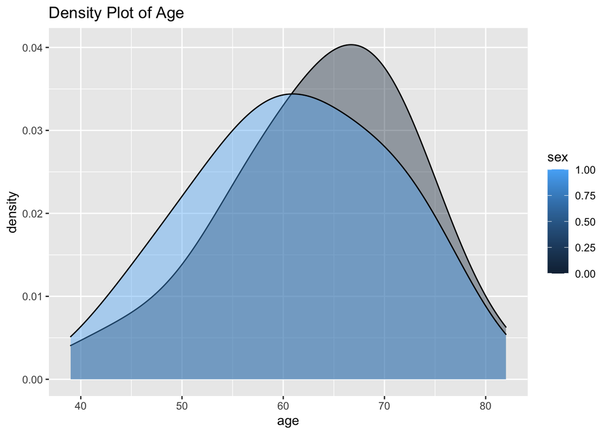

ECOG performance score histogram is positively skewed and captures only 0,1,2,3 values from the scale. Focus on the left side of the histogram shows that the majority of patients do not suffer from life burden as a result of diagnosed lung cancer.

Same analogy can be observed in Karnofsky performance score histograms rated by patient and by psychican. Only a few extreme values on the left tailor up to 60.00 are visible and the negative skew displays the majority of patients not suffering from life burden as a result of diagnosed lung cancer.

Gender histogram of a dummy variable describes the dataset consisting mainly of male lung cancer cases (Male=0). Sex geometric density is also displayed on a plot below, which show the occurance of lung cancer among females and males. Whereas in females the distribution is almost symmetrical with median around the age of 60, for males the density is higher and the peak is observed in range (65,70) years old.

# Kaplan-Meier Survival Model

In order to compare the lung cancer survival among patients, the analysis of the models has to be made. The Kaplan–Meier estimator, known as the product limit estimation, is a non-parametric statistic used to estimate the survival function from lifetime duration data. We used it in order to measure the fraction of patients living for a certain amount of time after lung cancer diagnosis and treatment.

Horizontal axis displays the number of days survived by a patient, whereas the vertical axis illustrates the survival probability of a patient or the proportion of people surviving. A vertical drop in the curves indicates an event. The vertical tick mark on the curves means that a patient was censored at this time. Confidence interval is 5%.

```
##       records n.max n.start events   *rmean *se(rmean) median 0.95LCL 0.95UCL
## sex=0     103   103     103     82 339.1903   26.50534    284     223     353
## sex=1      64    64      64     38 460.2383   42.50540    426     345     641
```

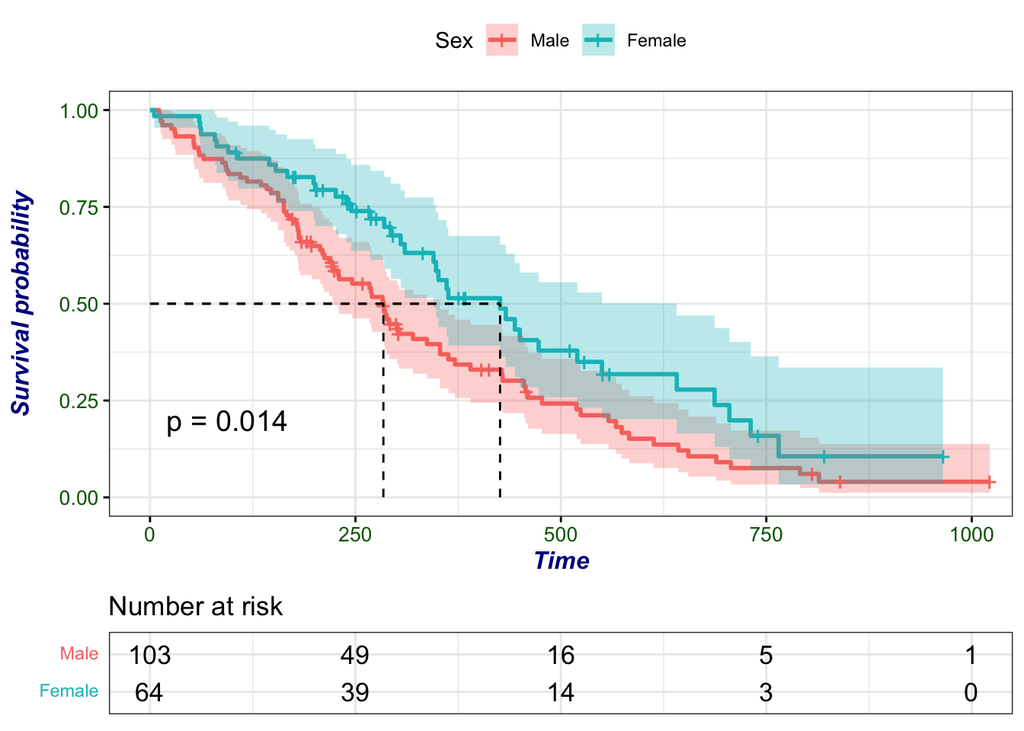

### Karnofsky performance score

Firstly, we will analyze the outcomes of the Karnofsky performance score indicator of a patient’s general status.

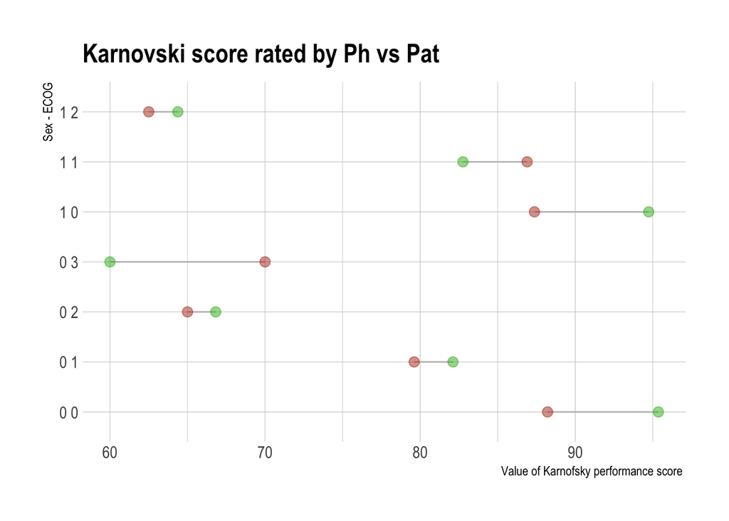

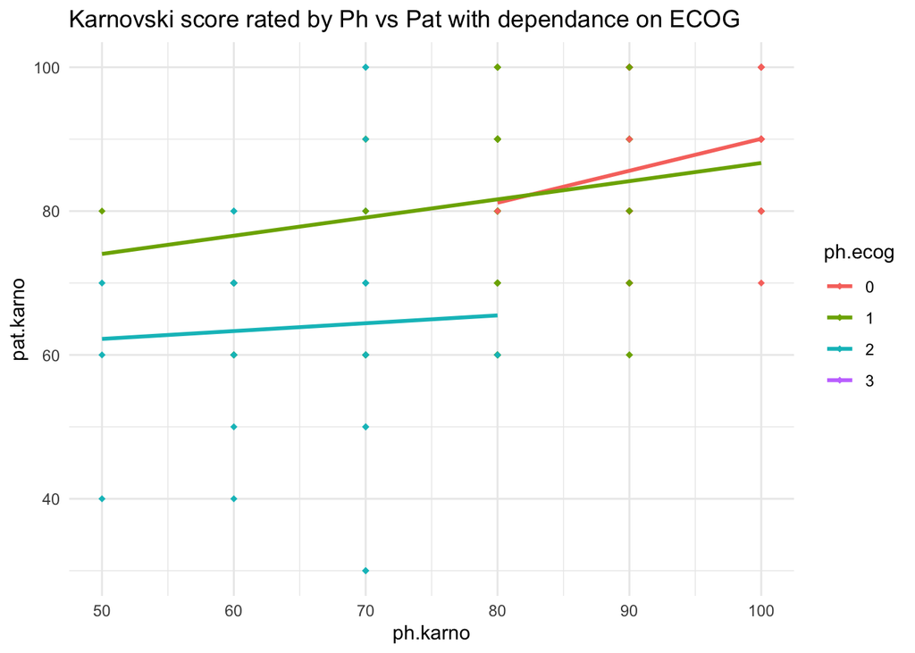

```
## [1] 0.5350275
```

The plot represents the comparison between the Karnofsky performance score rated by patient on a vertical axis, and by psychican on a horizontal axis corresponding to the ECOG performance score. Out of four ECOG outcomes, only 0,1,2 are visible on the plot, as the score =3 (Symptomatic, >50% in bed, but not bedbound) does not correspond to any Karnovski interval on the visible plot. This also proves that patients are more detailed but also less strictly assessed by the Karnofsky score. * Karnovsky (80,100) corresponds to ECOG = 0, which is an active patient without major inabilities * Karnovsky wide (50,100) is summed up into ECOG = 1, which is difficult to evaluate the actual status of a patient, however rather not bed bound, but incapable of working * Karnovsky (50,80) corresponds to ECOG = 2, which probably indicates the worst life-being status of all presented here

### ECOG

Secondly, we will analyze the outcomes of the ECOG performance score indicator of a patient’s performance status.

```r
#ECOG Performance status:
#0  Fully active; no performance restrictions.
#1  Strenuous physical activity restricted; fully ambulatory and able to carry out light work.
#2  Capable of all self-care but unable to carry out any work activities. Up and about >50% of waking hours.
#3  Capable of only limited self-care; confined to bed or chair >50% of waking hours.
#4  Completely disabled; cannot carry out any self-care; totally confined to bed or chair.
```

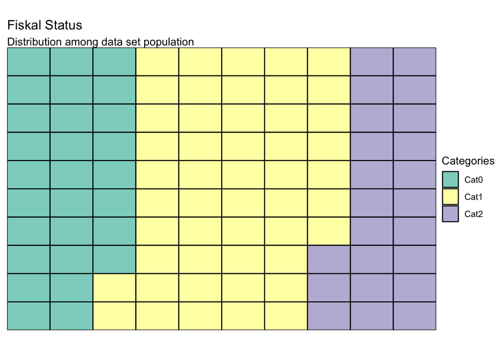

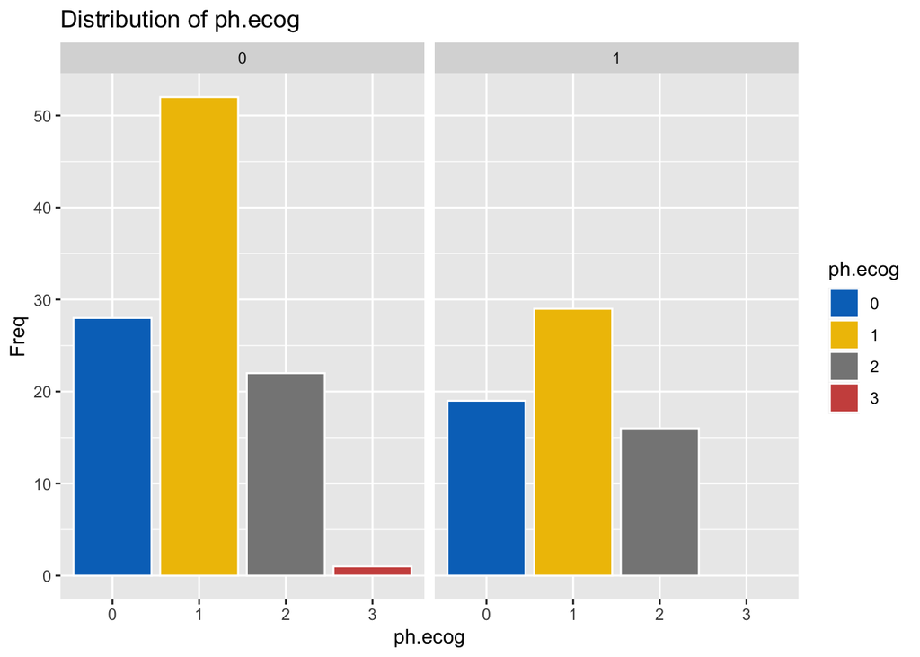

```
##           records n.max n.start events   *rmean *se(rmean) median 0.95LCL
## ph.ecog=0      47    47      47     27 456.2717   47.96911    371     337
## ph.ecog=1      81    81      81     59 400.6064   32.54056    345     269
## ph.ecog=2      38    38      38     33 259.7744   38.33524    199     156
## ph.ecog=3       1     1       1      1 118.0000    0.00000    118      NA
##           0.95UCL
## ph.ecog=0     643
## ph.ecog=1     460
## ph.ecog=2     291
## ph.ecog=3      NA
```

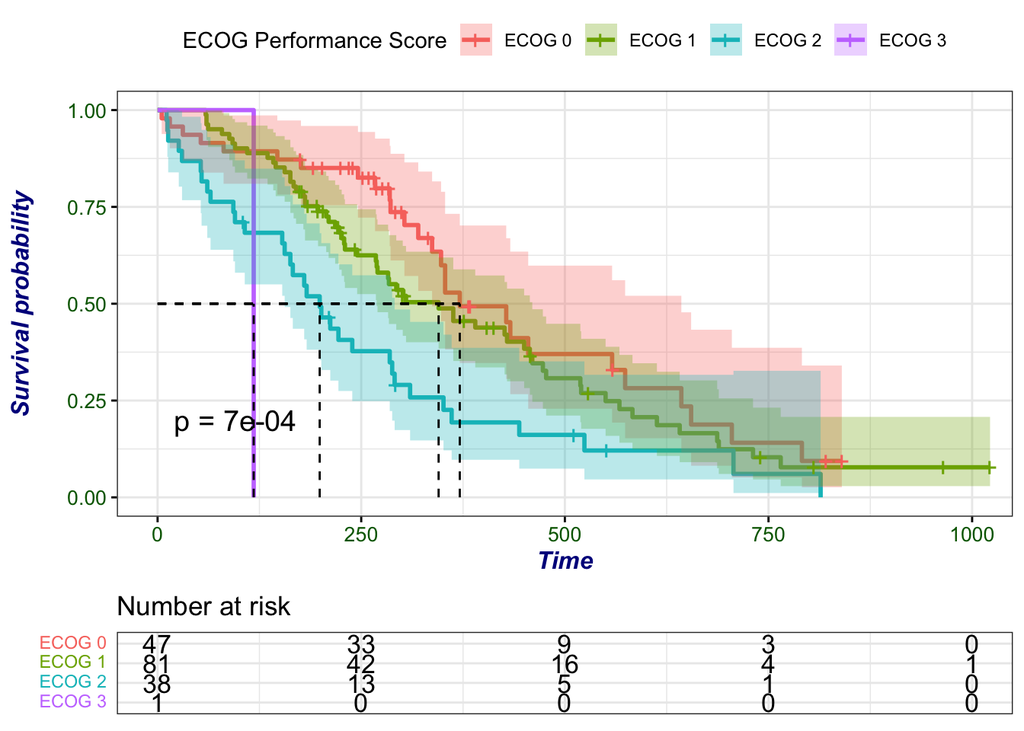

Kaplan-Meier Survival estimation is introduced again. Horizontal axis displays the number of days survived by a patient, whereas the vertical axis illustrates the survival probability of a patient or the proportion of people surviving. A vertical drop in the curves indicates an event. The vertical tick mark on the curves means that a patient was censored at this time. Confidence interval is 5%.

# Models Comparison and Selection

The final part of the report consists of comparison and selection of models as well as main conclusions.

In order to do so, the formula of lung cancer survival has been created, where time is a dependent variable and independent variables are: sex, age, meal.cal, ph.ecog, ph.karno and wt.loss. We use only one Karnovsky variable in the model, thus the one rated by a psychican, which gives a more relevant outcome than the one rated by a patient.

```r
formula <- Surv(time, status) ~ sex + age + meal.cal + ph.ecog +ph.karno + wt.loss
```

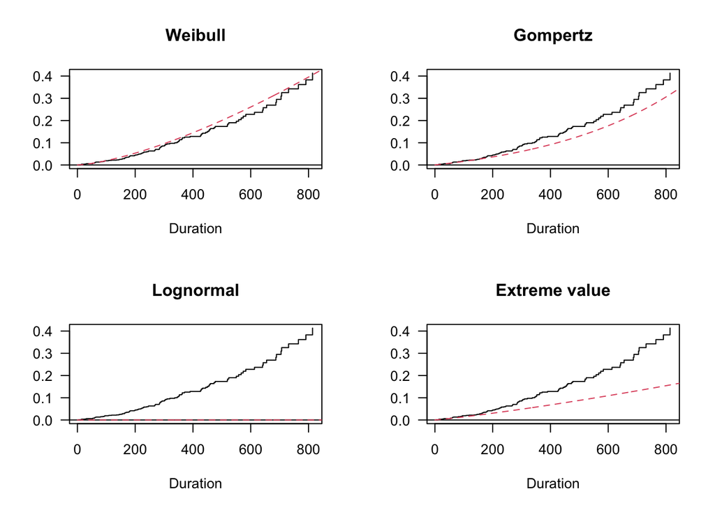

```r
oldpar <- par(mfrow = c(2, 2))
fit.cr <- coxreg(formula, data = data)
fit.w <- phreg(formula, data = data)
fit.g <- phreg(formula, data = data,
               dist = "gompertz")
fit.ln <- phreg(formula, data = data,
                dist = "lognormal")
fit.ev <- phreg(formula, data = data,
                dist = "ev")
check.dist(fit.cr, fit.w, printLegend = FALSE)
check.dist(fit.cr, fit.g, printLegend = FALSE)
check.dist(fit.cr, fit.ln, printLegend = FALSE)
check.dist(fit.cr, fit.ev, printLegend = FALSE)
```

```r
par(oldpar)
```

## Weibull Regression Conclusions

Confidence interval is 5%.

```r
fit <- phreg(formula, data = data, dist = "weibull")
fit
```

```
## Call:
## phreg(formula = formula, data = data, dist = "weibull")
##
## Covariate          W.mean      Coef Exp(Coef)  se(Coef)    Wald p
## sex
##                0    0.579     0         1           (reference)
##                1    0.421    -0.646     0.524     0.206     0.002
## age                62.083     0.007     1.007     0.012     0.562
## meal.cal          949.865    -0.000     1.000     0.000     0.749
## ph.ecog
##                0    0.309     0         1           (reference)
##                1    0.520     0.483     1.620     0.332     0.146
##                2    0.169     1.414     4.113     0.491     0.004
##                3    0.002     2.404    11.066     1.150     0.037
## ph.karno
##               50    0.037     0         1           (reference)
##               60    0.072     1.189     3.283     0.672     0.077
##               70    0.119     1.225     3.404     0.632     0.053
##               80    0.281     1.374     3.951     0.637     0.031
##               90    0.322     1.435     4.198     0.654     0.028
##              100    0.169     1.453     4.276     0.736     0.048
## wt.loss            10.019    -0.014     0.987     0.008     0.086
##
## log(scale)                    7.326               0.767     0.000
## log(shape)                    0.370               0.073     0.000
##
## Events                    120
## Total time at risk         51759
## Max. log. likelihood      -825.86
## LR test statistic         30.42
## Degrees of freedom        12
## Overall p-value           0.00241141
```

```r
#The p-value of a test gives the probability of observing a test statistic as extreme as the one observed, if the null hypothesis were true. For the Wald test: p = P(|Z| > |Tobs|), where Z ∼ N(0,1) is a standard normal random variable.
```

The analysis of the coefficients and the p-values show that variables, which are significant are: * sex with p-vale = 0.002, * ph.ecog only from the moment of scores equal to 2 (p-value = 0.004 ) and 3 (p-value = 0.037) * ph.karno only from the moment of scores equal to: 80 (p-value = 0.031), 90 (p-value = 0.028) and 100 (p-value = 0.048 ).

For the purpose of this research we can sum up, that the age of a patient, calories daily consumed at meals and weight loss are not relevant in terms of lung cancer survival analysis.

What actually matters, is the gender of patients suffering from lung cancer. Males survival after the diagnosis and treatment is lower than among females in time duration.

The most impact on that outcome has an ECOG performance score of 2 and 3, which indicates a patient’s performance status on general well-being with cancer on the level of symptomatic, but spending around 50% in bed during the day. Patients assessed by higher scores survive less number of days after the treatment.